# Final_Project_Full_Code_Notebook_EasyVisa

## Hyperparameter Tuning - XGBoost Classifier

```python
%%time
# measures the execution time of the entire code cell

# random_state=1: ensures reproducibility
# Choose the type of classifier.
xgb_tuned = XGBClassifier(random_state=1, eval_metric="logloss")

# searching over 3x3×2×3x2 = 108 combinations of parameters

# Grid of parameters to choose from
parameters = {
    "n_estimators": np.arange(50,110,25),
    "scale_pos_weight": [1,2,5],
    "subsample": [0.9, 1],
    "learning_rate": [0.01,0.1,0.05],
    "gamma": [1,3]
}

# Type of scoring used to compare parameter combinations
# custom scoring function that GridSearchCV can use to evaluate each combination of hyperparameters
# using F1 score instead of default accuracy
# to balance precision and recall, ideal for imbalanced datasets.
acc_scorer = metrics.make_scorer(metrics.f1_score)

# Run the grid search

#exhaustive search over all combinations in parameters.
# 5-fold cross-validation for each combination
#n_jobs=-1 runs it in parallel for speed

grid_obj = GridSearchCV(xgb_tuned, parameters, scoring=acc_scorer, cv=5, n_jobs=-1)

#Fits the grid search using the oversampled training data
grid_obj = grid_obj.fit(X_train_over_sampled_data, y_train_over_sampled_data)


# Set the clf to the best combination of parameters
xgb_tuned = grid_obj.best_estimator_ # Extracts the best-performing model from the grid search.

# Fit the best algorithm to the data.

# it re-trains the best model on the original training data
# To generalize on natural distributions again.
xgb_tuned.fit(X_train, y_train)
```

```
CPU times: total: 34.8 s
Wall time: 3min 8s
```

```
XGBClassifier(base_score=None, booster=None, callbacks=None,
              colsample_bylevel=None, colsample_bynode=None,
              colsample_bytree=None, device=None, early_stopping_rounds=None,
              enable_categorical=False, eval_metric='logloss',
              feature_types=None, gamma=1, grow_policy=None,
              importance_type=None, interaction_constraints=None,
              learning_rate=0.1, max_bin=None, max_cat_threshold=None,
              max_cat_to_onehot=None, max_delta_step=None, max_depth=None,
              max_leaves=None, min_child_weight=None, missing=nan,
              monotone_constraints=None, multi_strategy=None, n_estimators=75,
              n_jobs=None, num_parallel_tree=None, random_state=1, ...)
```

### Checking model performance on training set

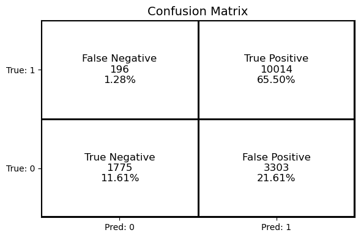

```python
calculate_confusion_matrix(xgb_tuned, X_train, y_train)
```

```python
xgb_tuned_model_train_perf = model_performance_metrics(
    xgb_tuned, X_train, y_train
)
xgb_tuned_model_train_perf
```

|  | Accuracy | Recall | Precision | F1 |
| --- | --- | --- | --- | --- |
| 0 | 0.771128 | 0.980803 | 0.751971 | 0.851277 |

### Checking model performance on validation set

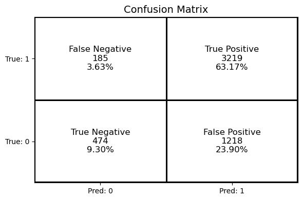

```python
calculate_confusion_matrix(xgb_tuned, X_val, y_val)
```

```python
xgb_tuned_model_val_perf = model_performance_metrics(
    xgb_tuned, X_val, y_val
)
xgb_tuned_model_val_perf
```

|  | Accuracy | Recall | Precision | F1 |
| --- | --- | --- | --- | --- |
| 0 | 0.724686 | 0.945652 | 0.72549 | 0.821069 |

### Evaluation Summary: Tuned XGBoost Performance

| Dataset | Accuracy | Recall | Precision | F1 Score |
| --- | --- | --- | --- | --- |
| **Training** | 0.7711 | 0.9808 | 0.7520 | 0.8513 |
| **Validation** | 0.7247 | 0.9457 | 0.7255 | 0.8211 |

### Key Observations:

- **F1 Score** is strong on both training (0.8513) and validation (0.8211), indicating good model performance and **reasonable generalization**.
- **Very high recall** (train: 0.98, val: 0.95) indicates the model is **excellent at catching most positive class cases** (“Certified”).  
  → This is ideal when **false negatives** are costly.
- **Precision is lower** (~75% → train, ~72% → val), meaning the model has a **moderate false positive rate** — this is expected when optimizing for recall/F1 in imbalanced datasets.
- **Slight overfitting** is visible (F1 drop ~3%), but this is still within an acceptable range for high-performing boosted models.
- **Accuracy** is around 72–77%, which aligns with class distribution and is less informative than F1 in this imbalanced setup.

### Summary:

> The tuned **XGBoostClassifier** is a high-recall model that generalizes well while slightly overfitting.  
> With its strong F1 score and excellent recall, it’s a strong candidate when **identifying positive cases (Certified)** is a top priority, and **some false positives are acceptable**.

# **Model Comparison and Final Model Selection**

```python
# training performance comparison

models_train_comp_df = pd.concat(
    [
        rfc_tuned_model_train_perf.T,
        abc_tuned_model_train_perf.T,
        gbc_tuned_model_train_perf.T,
        xgb_tuned_model_train_perf.T,
    ],
    axis=1,
)
models_train_comp_df.columns = [
    "Tuned Random Forest",
    "Tuned Adaboost Classifier",
    "Tuned Gradient Boost Classifier",
    "Tuned XGBoost Classifier",
]
print("=================================")
print("Training performance comparison:")
print("=================================")
models_train_comp_df
```

```
=================================
Training performance comparison:
=================================
```

|  | Tuned Random Forest | Tuned Adaboost Classifier | Tuned Gradient Boost Classifier | Tuned XGBoost Classifier |
| --- | --- | --- | --- | --- |
| Accuracy | 0.774529 | 0.754317 | 0.754055 | 0.771128 |
| Recall | 0.909990 | 0.881391 | 0.881587 | 0.980803 |
| Precision | 0.786107 | 0.779539 | 0.779172 | 0.751971 |
| F1 | 0.843524 | 0.827342 | 0.827222 | 0.851277 |

```python
# training performance comparison

models_validation_comp_df = pd.concat(
    [
        rfc_tuned_model_val_perf.T,
        abc_tuned_model_val_perf.T,
        gbc_tuned_model_val_perf.T,
        xgb_tuned_model_val_perf.T,
    ],
    axis=1,
)
models_validation_comp_df.columns = [
    "Tuned Random Forest",
    "Tuned Adaboost Classifier",
    "Tuned Gradient Boost Classifier",
    "Tuned XGBoost Classifier",
]
print("=================================")
print("Validation performance comparison:")
print("=================================")
models_validation_comp_df
```

```
=================================
Validation performance comparison:
=================================
```

|  | Tuned Random Forest | Tuned Adaboost Classifier | Tuned Gradient Boost Classifier | Tuned XGBoost Classifier |
| --- | --- | --- | --- | --- |
| Accuracy | 0.749804 | 0.756279 | 0.754317 | 0.724686 |
| Recall | 0.892479 | 0.878966 | 0.877791 | 0.945652 |
| Precision | 0.769699 | 0.782836 | 0.781381 | 0.725490 |
| F1 | 0.826554 | 0.828121 | 0.826785 | 0.821069 |

### Final Model Selection Based on Validation Performance

After comparing the performance of all tuned ensemble models across training and validation datasets, evaluation is based on the following:

#### Metric Importance:

- **F1 Score**: Primary metric used due to imbalanced classes (Certified vs Denied).
- **Recall**: Important for minimizing false negatives (i.e., missing Certified cases).
- **Precision**: Ensures false positives (wrongly approving Denied cases) are controlled.
- **Accuracy**: Less informative in imbalanced settings; used as a reference only.

#### Validation F1 Score Summary:

| Model | Train F1 | Val F1 | Generalization Gap |
| --- | --- | --- | --- |
| Random Forest | 0.8435 | 0.8266 | ~1.7% |
| **AdaBoost** | 0.8273 | **0.8281** | ~0.1% |
| Gradient Boosting | 0.8272 | 0.8268 | ~0.04% |
| XGBoost | 0.8513 | 0.8211 | ~3.0% (overfitting) |

### Next Step:

Evaluate the final model on the **test set** and evaluate

### Checking model performance on TEST set

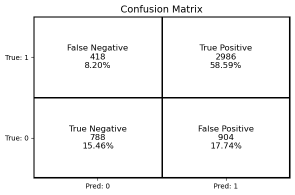

```python
calculate_confusion_matrix(abc_tuned, X_test, y_test)
```

```python
abc_tuned_model_test_perf = model_performance_metrics(
    abc_tuned, X_test, y_test
)
abc_tuned_model_test_perf
```

|  | Accuracy | Recall | Precision | F1 |
| --- | --- | --- | --- | --- |
| 0 | 0.740581 | 0.877203 | 0.767609 | 0.818755 |

### Final Model Evaluation on Test Set (Tuned AdaBoostClassifier)

After selecting the tuned AdaBoost model based on validation performance, we now evaluate it on the **unseen test set**.

#### Test Set Metrics:

| Metric | Value |
| --- | --- |
| **Accuracy** | 0.7406 |
| **Recall** | 0.8772 |
| **Precision** | 0.7676 |
| **F1 Score** | 0.8188 |

### Final Summary:

> The **tuned AdaBoostClassifier** has successfully generalized from training to validation to testing, maintaining a strong F1 score and a healthy balance of precision and recall.  
> hope, this makes it a **reliable, production-ready model** for predicting visa approval status.

# **Actionable Insights and Recommendations**

#### Key Takeaways:

- The tuned **AdaBoostClassifier** demonstrated strong, consistent performance across training, validation, and test sets — with an F1 Score of **0.82** on test data.
- The model shows a **high recall (87%)**, meaning it successfully identifies the majority of qualified visa applications ("Certified" cases).
- With **solid precision (77%)**, it also minimizes false approvals — helping maintain compliance and reduce risk.

#### Business Impact:

- This model can help **automate and accelerate visa approval screening**, ensuring faster processing for eligible applicants while flagging uncertain cases for manual review.
- By reducing both **false rejections** and **false approvals**, it supports better talent acquisition and lowers legal or compliance risks.

#### Recommendations:

1. **Integrate the model into the pre-screening workflow** to prioritize applications likely to be approved.
2. **Manually review edge cases** (low-confidence predictions), especially where prediction confidence is low but impact is high.
3. **Monitor model performance monthly** to detect any data drift or changes in visa patterns.
4. **Periodically retrain the model** with new data to maintain predictive quality and relevance.